# Single Cell V(D)J Analysis

UCD Bioinformatics Core

Last Updated March 23, 2022

# Single Cell V(D)J Analysis

## Packages

```r
if (!requireNamespace("BiocManager", quietly = TRUE)){
    install.packages("BiocManager")
}

if (!any(rownames(installed.packages()) == "ggplot2")){
  BiocManager::install("ggplot2")
}

if (!any(rownames(installed.packages()) == "knitr")){
  BiocManager::install("knitr")
}

if (!any(rownames(installed.packages()) == "kableExtra")){
  BiocManager::install("kableExtra")
}

if (!any(rownames(installed.packages()) == "dplyr")){
  BiocManager::install("dplyr")
}

if (!any(rownames(installed.packages()) == "tidyr")){
  BiocManager::install("tidyr")
}
if (!any(rownames(installed.packages()) == "magrittr")){
  BiocManager::install("magrittr")
}

if (!any(rownames(installed.packages()) == "scRepertoire")){
  BiocManager::install("scRepertoire")
}

library(ggplot2)
library(tidyr)
library(magrittr)
library(knitr)
library(kableExtra)
library(dplyr)
library(scRepertoire)
```

## Download Cell Ranger results

```r
options(timeout=1200)
download.file("https://raw.githubusercontent.com/ucdavis-bioinformatics-training/2022-March-Advanced-Topics-in-Single-Cell-RNA-Seq-VDJ/main/data_analysis/cellranger_vdj_results.zip", "cellranger_vdj_results.zip")
system("unzip cellranger_vdj_results.zip")
```

## Set-up

```r
experiment_name = "VDJ Example"
dataset_loc <- "./cellranger_vdj_results"
ids <- c("Pool1")
```

## Sequencing metrics

```r
metrics <- paste(dataset_loc, ids, "metrics_summary.csv", sep = "/")
metrics_table <- do.call("cbind", lapply(metrics, function(x) {
  as.data.frame(t(read.csv(x)))
  }))
colnames(metrics_table) <- ids
rownames(metrics_table) <- gsub(".", " ", rownames(metrics_table), fixed = TRUE)
metrics_table  %>%
  kable(caption = 'Cell Ranger Results') %>%
  pack_rows("Overview", 1, 3, label_row_css = "background-color: #666; color: #fff;") %>%
  pack_rows("Sequencing Characteristics", 4, 8, label_row_css = "background-color: #666; color: #fff;") %>%
  pack_rows("Mapping Characteristics", 9, 26, label_row_css = "background-color: #666; color: #fff;") %>%
  kable_styling("striped", fixed_thead = TRUE)
```

Cell Ranger Results

|  | Pool1 |
| --- | --- |
| **Overview** |  |
| Estimated Number of Cells | 5,703 |
| Mean Read Pairs per Cell | 49,067 |
| Number of Cells With Productive V J Spanning Pair | 4,392 |
| **Sequencing Characteristics** |  |
| Number of Read Pairs | 279,829,164 |
| Valid Barcodes | 94.4% |
| Q30 Bases in Barcode | 93.8% |
| Q30 Bases in RNA Read 1 | 91.6% |
| Q30 Bases in UMI | 93.5% |
| **Mapping Characteristics** |  |
| Reads Mapped to Any V D J Gene | 85.8% |
| Reads Mapped to TRA | 37.3% |
| Reads Mapped to TRB | 48.3% |
| Mean Used Read Pairs per Cell | 30,419 |
| Fraction Reads in Cells | 75.0% |
| Median TRA UMIs per Cell | 6 |
| Median TRB UMIs per Cell | 14 |
| Cells With Productive V J Spanning Pair | 77.0% |
| Cells With Productive V J Spanning TRA TRB Pair | 77.0% |
| Paired Clonotype Diversity | 1162.31 |
| Cells With TRA Contig | 90.0% |
| Cells With TRB Contig | 96.1% |
| Cells With CDR3 annotated TRA Contig | 87.1% |
| Cells With CDR3 annotated TRB Contig | 94.4% |
| Cells With V J Spanning TRA Contig | 88.8% |
| Cells With V J Spanning TRB Contig | 94.7% |
| Cells With Productive TRA Contig | 84.5% |
| Cells With Productive TRB Contig | 92.5% |

The majority of the following functions and figures come from [scRepertoire](https://ncborcherding.github.io/vignettes/vignette.html). We will be exploring and making changes to the code as we go, so please take notes and don’t be afraid to experiment and ask questions!

## Read in Cell Ranger VDJ Data

```r
clonotypes <- paste(dataset_loc, ids, "filtered_contig_annotations.csv", sep = "/")
vdj <- combineTCR(lapply(clonotypes, read.csv),
                  samples = ids,
                  ID = ids,
                  cells = "T-AB",
                  removeMulti = TRUE)
class(vdj)
```

```
## [1] "list"
```

```r
str(vdj)
```

```
## List of 1
##  $ Pool1_Pool1:'data.frame': 4913 obs. of  14 variables:
##   ..$ barcode : chr [1:4913] "Pool1_Pool1_AAACCTGAGCAAATCA-1" "Pool1_Pool1_AAACCTGAGCTACCTA-1" "Pool1_Pool1_AAACCTGAGTACGCGA-1" "Pool1_Pool1_AAACCTGCAGTCCTTC-1" ...
##   ..$ sample  : chr [1:4913] "Pool1" "Pool1" "Pool1" "Pool1" ...
##   ..$ ID      : chr [1:4913] "Pool1" "Pool1" "Pool1" "Pool1" ...
##   ..$ TCR1    : chr [1:4913] "TRAV12-1.TRAJ10.TRAC" "TRAV17.TRAJ9.TRAC" "TRAV6.TRAJ45.TRAC" NA ...
##   ..$ cdr3_aa1: chr [1:4913] "CVVNTGGGNKLTF" "CATDARAGGFKTIF" "CALDMAYSGGGADGLTF" NA ...
##   ..$ cdr3_nt1: chr [1:4913] "TGTGTGGTGAACACGGGAGGAGGAAACAAACTCACCTTT" "TGTGCTACGGACGCGCGGGCTGGAGGCTTCAAAACTATCTTT" "TGTGCTCTAGACATGGCGTATTCAGGAGGAGGTGCTGACGGACTCACCTTT" NA ...
##   ..$ TCR2    : chr [1:4913] "TRBV2.TRBJ2-2.None.TRBC2" "TRBV20-1.TRBJ1-4.None.TRBC1" NA "TRBV2.TRBJ2-1.None.TRBC2" ...
##   ..$ cdr3_aa2: chr [1:4913] "CASSAGTGELFF" "CSARDLGQREKLFF" NA "CASRDARDLVPQFF" ...
##   ..$ cdr3_nt2: chr [1:4913] "TGTGCCAGCAGCGCCGGGACCGGGGAGCTGTTTTTT" "TGCAGTGCTAGAGATCTGGGACAGCGTGAAAAACTGTTTTTT" NA "TGTGCCAGCAGGGATGCCCGGGACCTCGTCCCGCAGTTCTTC" ...
##   ..$ CTgene  : chr [1:4913] "TRAV12-1.TRAJ10.TRAC_TRBV2.TRBJ2-2.None.TRBC2" "TRAV17.TRAJ9.TRAC_TRBV20-1.TRBJ1-4.None.TRBC1" "TRAV6.TRAJ45.TRAC_NA" "NA_TRBV2.TRBJ2-1.None.TRBC2" ...
##   ..$ CTnt    : chr [1:4913] "TGTGTGGTGAACACGGGAGGAGGAAACAAACTCACCTTT_TGTGCCAGCAGCGCCGGGACCGGGGAGCTGTTTTTT" "TGTGCTACGGACGCGCGGGCTGGAGGCTTCAAAACTATCTTT_TGCAGTGCTAGAGATCTGGGACAGCGTGAAAAACTGTTTTTT" "TGTGCTCTAGACATGGCGTATTCAGGAGGAGGTGCTGACGGACTCACCTTT_NA" "NA_TGTGCCAGCAGGGATGCCCGGGACCTCGTCCCGCAGTTCT…
##   ..$ CTaa    : chr [1:4913] "CVVNTGGGNKLTF_CASSAGTGELFF" "CATDARAGGFKTIF_CSARDLGQREKLFF" "CALDMAYSGGGADGLTF_NA" "NA_CASRDARDLVPQFF" ...
##   ..$ CTstrict: chr [1:4913] "TRAV12-1.TRAJ10.TRAC_TGTGTGGTGAACACGGGAGGAGGAAACAAACTCACCTTT_TRBV2.TRBJ2-2.None.TRBC2_TGTGCCAGCAGCGCCGGGACCGGGGAGCTGTTTTTT" "TRAV17.TRAJ9.TRAC_TGTGCTACGGACGCGCGGGCTGGAGGCTTCAAAACTATCTTT_TRBV20-1.TRBJ1-4.None.TRBC1_TGCAGTGCTAGAGATCTGGGAC"| __truncated__ "TRAV6.TRAJ45.…
##   ..$ cellType: chr [1:4913] "T-AB" "T-AB" "T-AB" "T-AB" ...
```

```r
class(vdj[[1]])
```

```
## [1] "data.frame"
```

```r
head(vdj[[1]])
```

```
##                          barcode sample    ID                 TCR1
## 1 Pool1_Pool1_AAACCTGAGCAAATCA-1  Pool1 Pool1 TRAV12-1.TRAJ10.TRAC
## 2 Pool1_Pool1_AAACCTGAGCTACCTA-1  Pool1 Pool1    TRAV17.TRAJ9.TRAC
## 3 Pool1_Pool1_AAACCTGAGTACGCGA-1  Pool1 Pool1    TRAV6.TRAJ45.TRAC
## 4 Pool1_Pool1_AAACCTGCAGTCCTTC-1  Pool1 Pool1                 <NA>
## 5 Pool1_Pool1_AAACCTGCATCCCATC-1  Pool1 Pool1 TRAV13-2.TRAJ30.TRAC
## 6 Pool1_Pool1_AAACCTGGTAAATGTG-1  Pool1 Pool1                 <NA>
##            cdr3_aa1                                            cdr3_nt1
## 1     CVVNTGGGNKLTF             TGTGTGGTGAACACGGGAGGAGGAAACAAACTCACCTTT
## 2    CATDARAGGFKTIF          TGTGCTACGGACGCGCGGGCTGGAGGCTTCAAAACTATCTTT
## 3 CALDMAYSGGGADGLTF TGTGCTCTAGACATGGCGTATTCAGGAGGAGGTGCTGACGGACTCACCTTT
## 4              <NA>                                                <NA>
## 5       CAENRDDKIIF                   TGTGCAGAGAACAGAGATGACAAGATCATCTTT
## 6              <NA>                                                <NA>
##                          TCR2         cdr3_aa2
```

[output cut: 48 more lines]

## Number of unique clonotypes

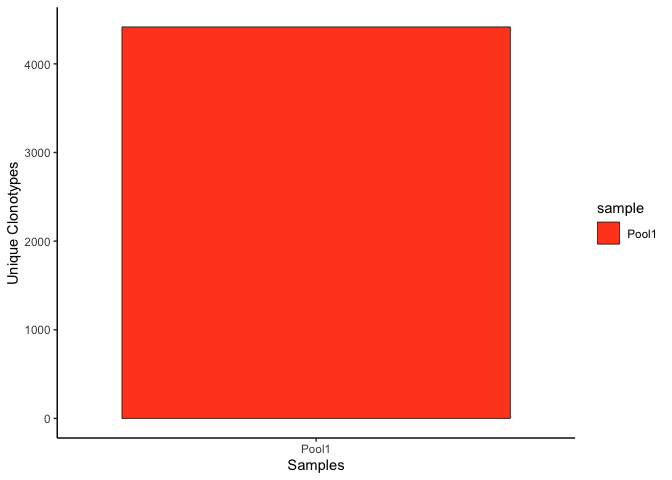

```r
quantContig(vdj, cloneCall="aa", group = "sample", scale = FALSE)
```

## Distribution of clonotypes by abundance

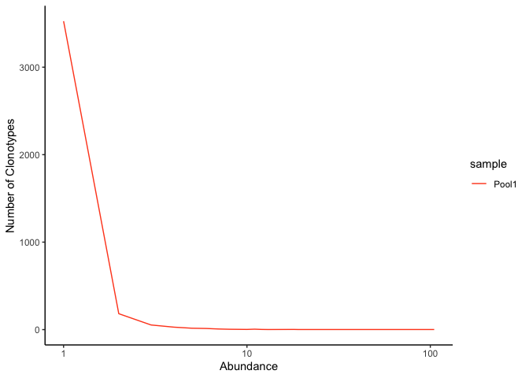

```r
abundanceContig(vdj, cloneCall = "gene", group = "sample", scale = FALSE)
```

## Contig length distribution

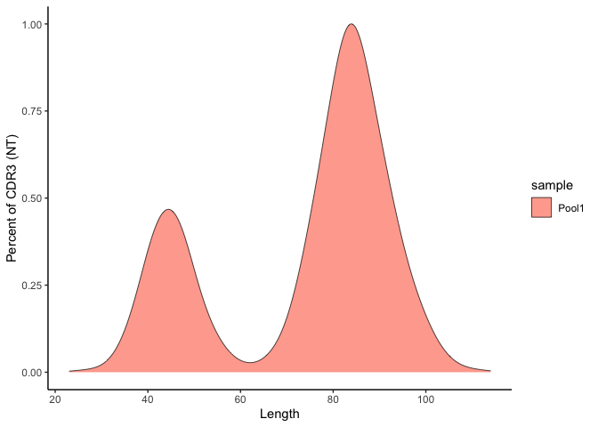

```r
lengthContig(vdj, cloneCall="nt", scale=TRUE, chains = "combined", group="sample")
```

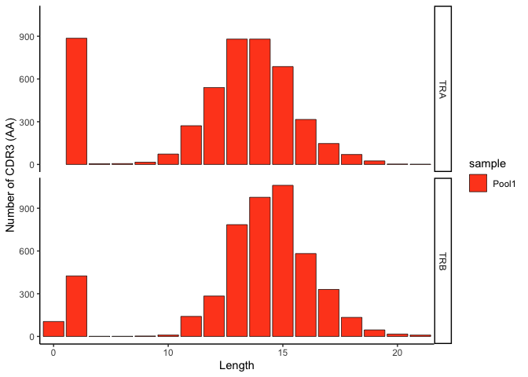

```r
lengthContig(vdj, cloneCall="aa", chains = "single", group = "sample")
```

### Shared clonotypes

This function does not make much sense with only one sample, and is included just for the purposes of demonstration.

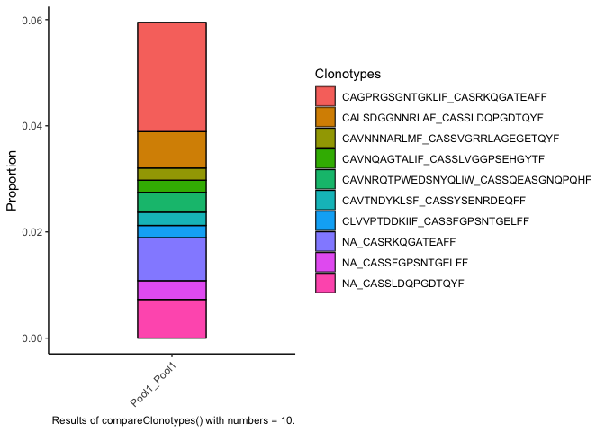

```r
compareClonotypes(vdj, numbers = 10, cloneCall = "aa", graph = "alluvial") +
  theme(axis.text.x = element_text(angle = 45, hjust = 1)) +
  labs(caption = "Results of compareClonotypes() with numbers = 10.")
```

### Relative abundance of clones by frequency

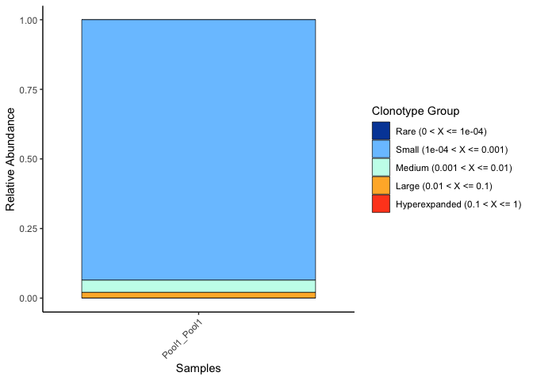

```r
clonalHomeostasis(vdj, cloneCall = "aa") +
  theme(axis.text.x = element_text(angle = 45, hjust = 1))
```

### Relative abundance of clones by index

Clonal index 1 represents the most frequent clone in a given sample, while index 1000 represents the 1000th most frequent clone.

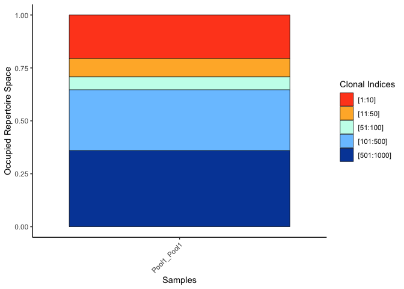

```r
clonalProportion(vdj, cloneCall = "aa", split = c(10, 50, 100, 500, 1000)) +
  theme(axis.text.x = element_text(angle = 45, hjust = 1))
```

### Overlap analysis

Clonal overlap is scaled to the number of unique clonotypes in the smaller sample. This code errors on fewer than two samples.

```r
clonalOverlap(vdj, cloneCall = "gene+nt")
```

## Clonal diversity

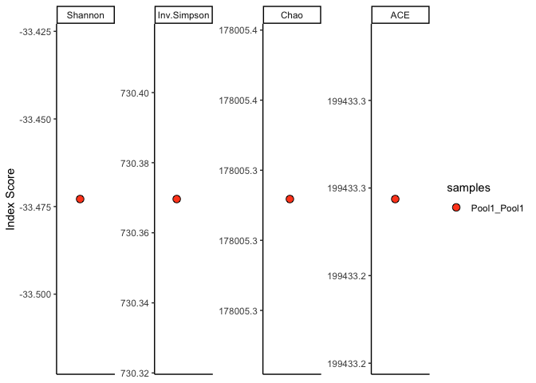

```r
clonalDiversity(vdj, cloneCall = "aa", group = "samples")
```

## TCR clustering

This is slow. I suggest skipping it for now so that you don’t get stuck at this point.

```r
tcr.clusters <- clusterTCR(vdj[[1]], chain = "TCRA", sequence = "aa", threshold = 0.9)
```

## Combine V(D)J and expression data

In the terminal, from your project directory, run `scp username@tadpole.genomecenter.ucdavis.edu:/share/workshop/vdj_workshop/R_objects/seurat_object.rds .`.

```r
library(Seurat)
expression <- readRDS("seurat_object.rds")
expression$barcode <- sapply(strsplit(colnames(expression), split = "-"), "[[", 1)
expression <- RenameCells(expression, new.names = expression$barcode)
vdj <- lapply(vdj, function (x) {
  b = sapply(strsplit(sapply(strsplit(x$barcode, split = "_"), "[[", 3), split = "-"), "[[", 1)
  x$barcode = b
  x
  })
expression <- combineExpression(vdj, expression, cloneCall="gene")
head(expression@meta.data)
```

```
##                  orig.ident nCount_RNA nFeature_RNA percent.mito     S.Score
## AAACCTGCAGACTCGC conv_COVID       7321         2560    0.3824614 -0.04879952
## AAACGGGTCTGGGCCA conv_COVID       6765         2128    0.8869180 -0.01441873
## AAACGGGTCTTAGAGC conv_COVID      11471         2964    0.4794700 -0.05208459
## AAAGATGCATCCTAGA conv_COVID       9610         2605    0.9261186 -0.02179640
## AAAGCAAAGAGTAAGG conv_COVID       7242         2051    0.3314002  0.11342246
## AAAGCAAAGCCTATGT conv_COVID       1016          772    1.6732283  0.03533120
##                     G2M.Score Phase  old.ident RNA_snn_res.0.25
## AAACCTGCAGACTCGC -0.026197357    G1 conv_COVID                6
## AAACGGGTCTGGGCCA -0.031983183    G1 conv_COVID                0
## AAACGGGTCTTAGAGC -0.003787519    G1 conv_COVID                0
## AAAGATGCATCCTAGA -0.011175856    G1 conv_COVID                6
## AAAGCAAAGAGTAAGG  0.019373865     S conv_COVID                2
## AAAGCAAAGCCTATGT -0.017761709     S conv_COVID                5
##                  RNA_snn_res.0.75 RNA_snn_res.1.25 RNA_snn_res.1.75
## AAACCTGCAGACTCGC                8                8                9
## AAACGGGTCTGGGCCA                0                0                3
## AAACGGGTCTTAGAGC                0                0                3
## AAAGATGCATCCTAGA                8                8                9
## AAAGCAAAGAGTAAGG                2                2                1
## AAAGCAAAGCCTATGT                7                7                5
##                  RNA_snn_res.2.25 RNA_snn_res.2.75 RNA_snn_res.3.25
## AAACCTGCAGACTCGC                8                6                6
## AAACGGGTCTGGGCCA                1               13               10
## AAACGGGTCTTAGAGC                1                1               10
## AAAGATGCATCCTAGA                8                6                6
## AAAGCAAAGAGTAAGG                3                2                1
## AAAGCAAAGCCTATGT                7                5                4
##                  RNA_snn_res.3.75 seurat_clusters finalcluster samplecluster
## AAACCTGCAGACTCGC                6               6            8  conv_COVID-8
## AAACGGGTCTGGGCCA               11              11            0  conv_COVID-0
## AAACGGGTCTTAGAGC               11              11            0  conv_COVID-0
## AAAGATGCATCCTAGA                6               6            8  conv_COVID-8
## AAAGCAAAGAGTAAGG                0               0            2  conv_COVID-2
## AAAGCAAAGCCTATGT                5               5            7  conv_COVID-7
##                           barcode
## AAACCTGCAGACTCGC             <NA>
## AAACGGGTCTGGGCCA             <NA>
## AAACGGGTCTTAGAGC AAACGGGTCTTAGAGC
## AAAGATGCATCCTAGA AAAGATGCATCCTAGA
```

[output cut: 22 more lines]

```
## AAAGCAAAGCCTATGT                            <NA>
##                                                                                                                                                        CTstrict
## AAACCTGCAGACTCGC                                                                                                                                           <NA>
## AAACGGGTCTGGGCCA                                                                                                                                           <NA>
## AAACGGGTCTTAGAGC                TRAV5.TRAJ29.TRAC_TGTGCAGAGAAAGGGGAAACACCTCTTGTCTTT_TRBV7-2.TRBJ1-6.None.TRBC1_TGTGCCAGCAGCTTAGCGGGAGAGGGTAATAATTCACCCCTCCACTTT
## AAAGATGCATCCTAGA TRAV14/DV4.TRAJ34.TRAC_TGTGCAATGAGAGCCGACCCTTATAACACCGACAAGCTCATCTTT_TRBV24-1.TRBJ2-1.None.TRBC2_TGTGCCACCGGGGGGAGGGCCGGGACCTACAATGAGCAGTTCTTC
## AAAGCAAAGAGTAAGG                                                                         NA_NA_TRBV10-3.TRBJ1-5.None.TRBC1_TGTGCCATCAGTGAGAGGGGTCAGCCCCAGCATTTT
## AAAGCAAAGCCTATGT                                                                                                                                           <NA>
##                     Frequency                  cloneType
## AAACCTGCAGACTCGC           NA                       <NA>
## AAACGGGTCTGGGCCA           NA                       <NA>
## AAACGGGTCTTAGAGC 0.0004128819 Small (1e-04 < X <= 0.001)
## AAAGATGCATCCTAGA 0.0004128819 Small (1e-04 < X <= 0.001)
## AAAGCAAAGAGTAAGG 0.0008257638 Small (1e-04 < X <= 0.001)
## AAAGCAAAGCCTATGT           NA                       <NA>
```

### Find markers for “large” clones

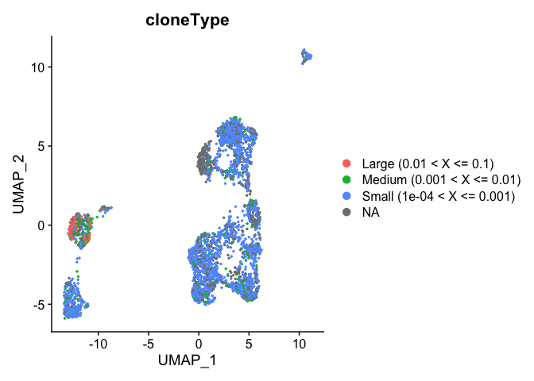

```r
DimPlot(expression, group.by = "cloneType")
```

```r
Idents(expression) <- "cloneType"
large.markers <-FindMarkers(expression, ident.1 = "Large (0.01 < X <= 0.1)")
head(large.markers)
```

```
##                 p_val avg_log2FC pct.1 pct.2     p_val_adj
## TRAV25  3.144420e-188   2.577545 0.591 0.027 1.150889e-183
## TRBV6-5 2.415113e-176   3.507570 0.787 0.067 8.839557e-172
## GZMH    1.530561e-173   3.002632 0.874 0.087 5.602005e-169
## FGFBP2  3.202763e-154   2.845364 0.795 0.078 1.172243e-149
## CCL5    2.263650e-116   2.910292 0.961 0.181 8.285185e-112
## CST7     1.057213e-80   2.082753 0.827 0.182  3.869504e-76
```

```r
Idents(expression) <- "orig.ident"
```

### Split V(D)J data into separate samples and re-run scRepertoire functions

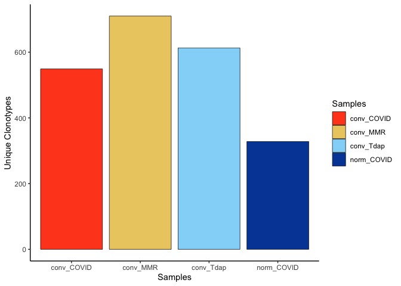

```r
vdj <- expression2List(expression, group = "orig.ident")
quantContig(vdj, cloneCall="aa", scale = FALSE)
```

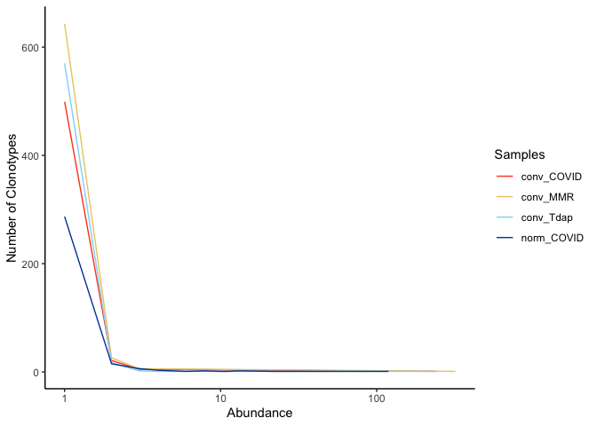

```r
abundanceContig(vdj, cloneCall = "gene", scale = FALSE)
```

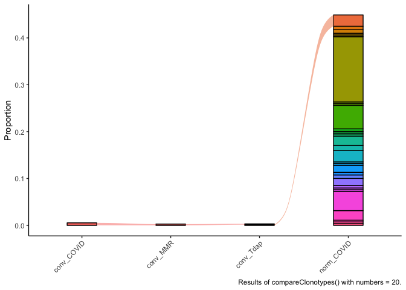

```r
compareClonotypes(vdj, numbers = 20, cloneCall = "aa", graph = "alluvial") +
  guides(fill = "none") +
  theme(axis.text.x = element_text(angle = 45, hjust = 1)) +
  labs(caption = "Results of compareClonotypes() with numbers = 20.")
```

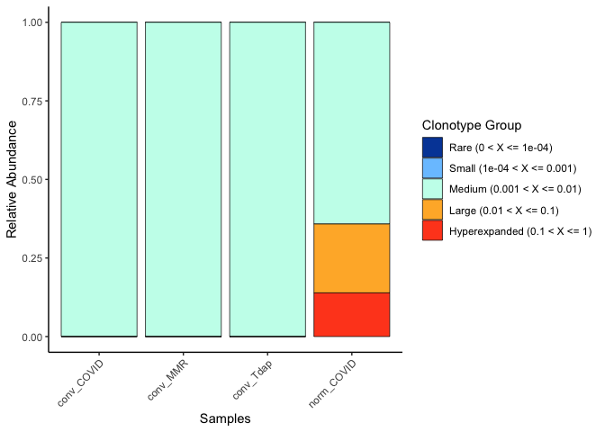

```r
clonalHomeostasis(vdj, cloneCall = "aa") +
  theme(axis.text.x = element_text(angle = 45, hjust = 1))
```

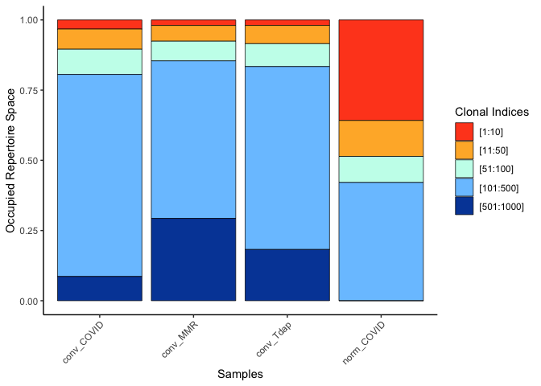

```r
clonalProportion(vdj, cloneCall = "aa", split = c(10, 50, 100, 500, 1000)) +
  theme(axis.text.x = element_text(angle = 45, hjust = 1))
```

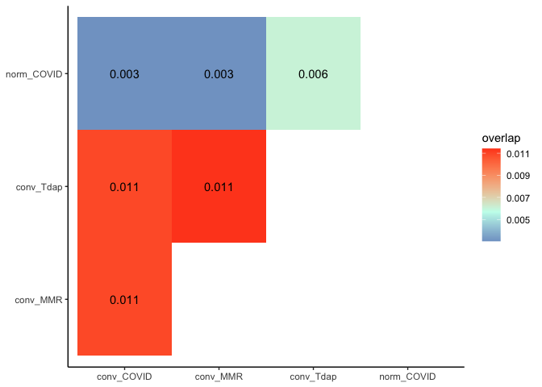

```r
clonalOverlap(vdj, cloneCall = "gene+nt")
```

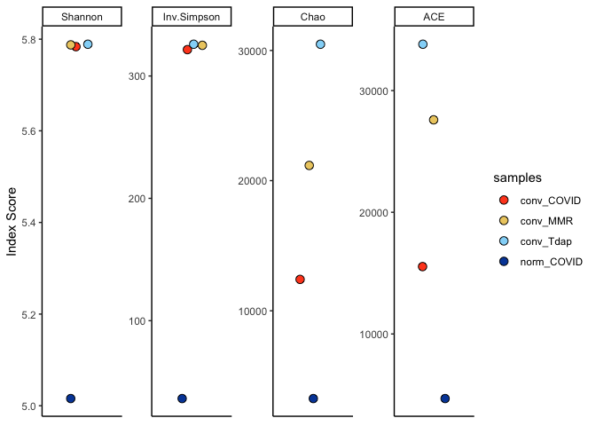

```r
clonalDiversity(vdj, cloneCall = "aa")
```

## Circos plots

This code is under construction! If we have time, I will attempt to update this and run it.

```r
?getCirclize
circles <- getCirclize(vdj, groupBy = "orig.ident" )

#Just assigning the normal colors to each cluster
grid.cols <- hue_pal()(length(unique(seurat$orig.ident)))
names(grid.cols) <- levels(seurat$orig.ident)

#Graphing the chord diagram
chordDiagram(circles, self.link = 1, grid.col = grid.cols)

data_to_circlize <- experiment.aggregate[[]][experiment.aggregate$RNA_snn_res.0.75 %in% b_cells & !is.na(experiment.aggregate$CTgene),]
dim(data_to_circlize)
head(data_to_circlize)

aa_seqs <- strsplit(as.character(unlist(data_to_circlize$CTaa)),split="_")
table(sapply(aa_seqs, length))
data_to_circlize$A_chain = sapply(aa_seqs, "[[", 1L)
data_to_circlize$B_chain = sapply(aa_seqs, "[[", 2L)

data_to_circlize$IGH = sapply(strsplit(data_to_circlize$CTstrict, split="_"), function(x) paste(unique(x[c(1)]),collapse="_"))
data_to_circlize$IGL = sapply(strsplit(data_to_circlize$CTstrict, split="_"), function(x) paste(unique(x[c(3)]),collapse="_"))

# get optimal sequence order from trivial plot
chordDiagram(data.frame(data_to_circlize$IGH[1:15], data_to_circlize$IGL[1:15], times = 1), annotationTrack = "grid" )
seq.order <- get.all.sector.index()
circos.clear()
```